# Risk Factor Analysis

## Outcome Variable

**Outcome Variable:** stunted

## Predictor Variables

**Intervention Variable:** impfloor

**Adjustment Set:**

- arm
- sex
- W_mage
- meducyrs
- feducyrs
- hhwealth_quart
- hfoodsec
- W_mhtcm
- W_mwtkg
- W_mbmi
- W_nrooms
- W_nchldlt5
- W_parity
- impsan
- safeh20
- delta_W_mage
- delta_meducyrs
- delta_feducyrs
- delta_hhwealth_quart
- delta_hfoodsec
- delta_W_mhtcm
- delta_W_mwtkg
- delta_W_mbmi
- delta_W_nrooms
- delta_W_nchldlt5
- delta_W_parity
- delta_impsan
- delta_safeh20

## Stratifying Variables

The analysis was stratified on these variable(s):

- agecat
- studyid
- country

## Data Summary

| agecat | studyid | country | impfloor | stunted | n_cell | n |
| --- | --- | --- | --- | --- | --- | --- |
| Birth | CMC-V-BCS-2002 | INDIA | 1 | 0 | 58 | 72 |
| Birth | CMC-V-BCS-2002 | INDIA | 1 | 1 | 14 | 72 |
| Birth | CMC-V-BCS-2002 | INDIA | 0 | 0 | 0 | 72 |
| Birth | CMC-V-BCS-2002 | INDIA | 0 | 1 | 0 | 72 |
| Birth | CONTENT | PERU | 1 | 0 | 2 | 2 |
| Birth | CONTENT | PERU | 1 | 1 | 0 | 2 |
| Birth | CONTENT | PERU | 0 | 0 | 0 | 2 |
| Birth | CONTENT | PERU | 0 | 1 | 0 | 2 |
| Birth | GMS-Nepal | NEPAL | 1 | 0 | 91 | 544 |
| Birth | GMS-Nepal | NEPAL | 1 | 1 | 9 | 544 |
| Birth | GMS-Nepal | NEPAL | 0 | 0 | 361 | 544 |
| Birth | GMS-Nepal | NEPAL | 0 | 1 | 83 | 544 |
| Birth | IRC | INDIA | 1 | 0 | 255 | 287 |
| Birth | IRC | INDIA | 1 | 1 | 32 | 287 |
| Birth | IRC | INDIA | 0 | 0 | 0 | 287 |
| Birth | IRC | INDIA | 0 | 1 | 0 | 287 |
| Birth | JiVitA-3 | BANGLADESH | 1 | 0 | 1054 | 22399 |
| Birth | JiVitA-3 | BANGLADESH | 1 | 1 | 340 | 22399 |
| Birth | JiVitA-3 | BANGLADESH | 0 | 0 | 13973 | 22399 |
| Birth | JiVitA-3 | BANGLADESH | 0 | 1 | 7032 | 22399 |
| Birth | JiVitA-4 | BANGLADESH | 1 | 0 | 226 | 2820 |
| Birth | JiVitA-4 | BANGLADESH | 1 | 1 | 81 | 2820 |
| Birth | JiVitA-4 | BANGLADESH | 0 | 0 | 1738 | 2820 |
| Birth | JiVitA-4 | BANGLADESH | 0 | 1 | 775 | 2820 |
| Birth | MAL-ED | BANGLADESH | 1 | 0 | 161 | 213 |
| Birth | MAL-ED | BANGLADESH | 1 | 1 | 35 | 213 |
| Birth | MAL-ED | BANGLADESH | 0 | 0 | 15 | 213 |
| Birth | MAL-ED | BANGLADESH | 0 | 1 | 2 | 213 |
| Birth | MAL-ED | BRAZIL | 1 | 0 | 49 | 60 |
| Birth | MAL-ED | BRAZIL | 1 | 1 | 9 | 60 |

[output cut: 162 more lines]

The following strata were considered:

- agecat: 24 months, studyid: CMC-V-BCS-2002, country: INDIA
- agecat: 24 months, studyid: CONTENT, country: PERU
- agecat: 24 months, studyid: GMS-Nepal, country: NEPAL
- agecat: 24 months, studyid: IRC, country: INDIA
- agecat: 24 months, studyid: JiVitA-3, country: BANGLADESH
- agecat: 24 months, studyid: JiVitA-4, country: BANGLADESH
- agecat: 24 months, studyid: MAL-ED, country: BANGLADESH
- agecat: 24 months, studyid: MAL-ED, country: BRAZIL
- agecat: 24 months, studyid: MAL-ED, country: INDIA
- agecat: 24 months, studyid: MAL-ED, country: NEPAL
- agecat: 24 months, studyid: MAL-ED, country: PERU
- agecat: 24 months, studyid: MAL-ED, country: SOUTH AFRICA
- agecat: 24 months, studyid: MAL-ED, country: TANZANIA, UNITED REPUBLIC OF
- agecat: 24 months, studyid: NIH-Birth, country: BANGLADESH
- agecat: 24 months, studyid: NIH-Crypto, country: BANGLADESH
- agecat: 24 months, studyid: PROVIDE, country: BANGLADESH
- agecat: 6 months, studyid: CMC-V-BCS-2002, country: INDIA
- agecat: 6 months, studyid: CONTENT, country: PERU
- agecat: 6 months, studyid: GMS-Nepal, country: NEPAL
- agecat: 6 months, studyid: IRC, country: INDIA
- agecat: 6 months, studyid: JiVitA-3, country: BANGLADESH
- agecat: 6 months, studyid: JiVitA-4, country: BANGLADESH
- agecat: 6 months, studyid: MAL-ED, country: BANGLADESH
- agecat: 6 months, studyid: MAL-ED, country: BRAZIL
- agecat: 6 months, studyid: MAL-ED, country: INDIA
- agecat: 6 months, studyid: MAL-ED, country: NEPAL
- agecat: 6 months, studyid: MAL-ED, country: PERU
- agecat: 6 months, studyid: MAL-ED, country: SOUTH AFRICA
- agecat: 6 months, studyid: MAL-ED, country: TANZANIA, UNITED REPUBLIC OF
- agecat: 6 months, studyid: NIH-Birth, country: BANGLADESH
- agecat: 6 months, studyid: NIH-Crypto, country: BANGLADESH
- agecat: 6 months, studyid: PROVIDE, country: BANGLADESH
- agecat: Birth, studyid: CMC-V-BCS-2002, country: INDIA
- agecat: Birth, studyid: CONTENT, country: PERU
- agecat: Birth, studyid: GMS-Nepal, country: NEPAL
- agecat: Birth, studyid: IRC, country: INDIA
- agecat: Birth, studyid: JiVitA-3, country: BANGLADESH
- agecat: Birth, studyid: JiVitA-4, country: BANGLADESH
- agecat: Birth, studyid: MAL-ED, country: BANGLADESH
- agecat: Birth, studyid: MAL-ED, country: BRAZIL
- agecat: Birth, studyid: MAL-ED, country: INDIA
- agecat: Birth, studyid: MAL-ED, country: NEPAL
- agecat: Birth, studyid: MAL-ED, country: PERU
- agecat: Birth, studyid: MAL-ED, country: SOUTH AFRICA
- agecat: Birth, studyid: MAL-ED, country: TANZANIA, UNITED REPUBLIC OF
- agecat: Birth, studyid: NIH-Birth, country: BANGLADESH
- agecat: Birth, studyid: NIH-Crypto, country: BANGLADESH
- agecat: Birth, studyid: PROVIDE, country: BANGLADESH

### Dropped Strata

Some strata were dropped due to rare outcomes:

- agecat: Birth, studyid: CMC-V-BCS-2002, country: INDIA
- agecat: Birth, studyid: CONTENT, country: PERU
- agecat: Birth, studyid: IRC, country: INDIA
- agecat: Birth, studyid: MAL-ED, country: BANGLADESH
- agecat: Birth, studyid: MAL-ED, country: BRAZIL
- agecat: Birth, studyid: MAL-ED, country: INDIA
- agecat: Birth, studyid: MAL-ED, country: NEPAL
- agecat: Birth, studyid: MAL-ED, country: SOUTH AFRICA
- agecat: Birth, studyid: MAL-ED, country: TANZANIA, UNITED REPUBLIC OF
- agecat: Birth, studyid: PROVIDE, country: BANGLADESH
- agecat: 6 months, studyid: CMC-V-BCS-2002, country: INDIA
- agecat: 6 months, studyid: CONTENT, country: PERU
- agecat: 6 months, studyid: IRC, country: INDIA
- agecat: 6 months, studyid: MAL-ED, country: BANGLADESH
- agecat: 6 months, studyid: MAL-ED, country: BRAZIL
- agecat: 6 months, studyid: MAL-ED, country: INDIA
- agecat: 6 months, studyid: MAL-ED, country: SOUTH AFRICA
- agecat: 6 months, studyid: MAL-ED, country: TANZANIA, UNITED REPUBLIC OF
- agecat: 24 months, studyid: CMC-V-BCS-2002, country: INDIA
- agecat: 24 months, studyid: CONTENT, country: PERU
- agecat: 24 months, studyid: IRC, country: INDIA
- agecat: 24 months, studyid: MAL-ED, country: BRAZIL
- agecat: 24 months, studyid: MAL-ED, country: TANZANIA, UNITED REPUBLIC OF

## Methods Detail

We’re interested in the causal parameters $E[Y_a]$ for all values of $a \in \mathcal{A}$. These parameters represent the mean outcome if, possibly contrary to fact, we intervened to set all units to have $A=a$. Under the randomization and positivity assumptions, these are identified by the statistical parameters $\psi_a=E_W[E_{Y|A,W}(Y|A=a,W)]$. In addition, we’re interested in the mean of $Y$, $E[Y]$ under no intervention (the observed mean). We will estimate these parameters by using SuperLearner to fit the relevant likelihood factors – $E_{Y|A,W}(Y|A=a,W)$ and $p(A=a|W)$, and then updating our likelihood fit using a joint TMLE.

For unadjusted analyses ($W=\{\}$), initial likelihoods were estimated using Lrnr_glm to estimate the simple $E(Y|A)$ and Lrnr_mean to estimate $p(A)$. For adjusted analyses, a small library containing Lrnr_glmnet, Lrnr_xgboost, and Lrnr_mean was used.

Having estimated these parameters, we will then use the delta method to estimate relative risks and attributable risks relative to a prespecified baseline level of $A$.

# Results Detail

## Results Plots

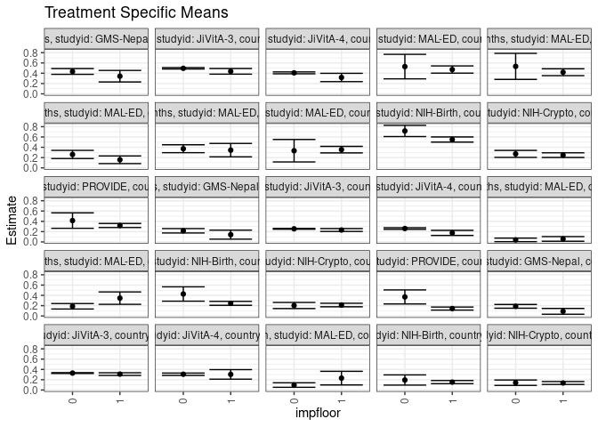

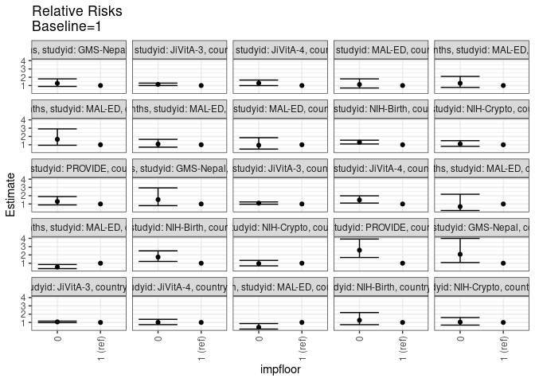

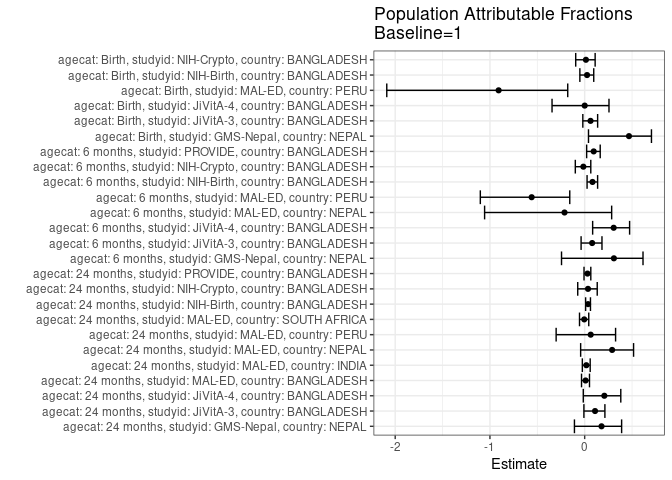

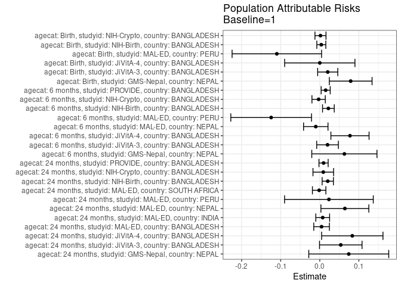

## Results Table

### Parameter: TSM

| agecat | studyid | country | intervention_level | baseline_level | estimate | ci_lower | ci_upper |
| --- | --- | --- | --- | --- | --- | --- | --- |
| Birth | GMS-Nepal | NEPAL | 1 | NA | 0.0900000 | 0.0338578 | 0.1461422 |
| Birth | GMS-Nepal | NEPAL | 0 | NA | 0.1869369 | 0.1506403 | 0.2232335 |
| Birth | JiVitA-3 | BANGLADESH | 1 | NA | 0.3087705 | 0.2827439 | 0.3347972 |
| Birth | JiVitA-3 | BANGLADESH | 0 | NA | 0.3288986 | 0.3212527 | 0.3365445 |
| Birth | JiVitA-4 | BANGLADESH | 1 | NA | 0.3034793 | 0.2106936 | 0.3962651 |
| Birth | JiVitA-4 | BANGLADESH | 0 | NA | 0.3063298 | 0.2836257 | 0.3290340 |
| Birth | MAL-ED | PERU | 1 | NA | 0.2307692 | 0.0982297 | 0.3633088 |
| Birth | MAL-ED | PERU | 0 | NA | 0.0965909 | 0.0528473 | 0.1403345 |
| Birth | NIH-Birth | BANGLADESH | 1 | NA | 0.1530774 | 0.1225155 | 0.1836393 |
| Birth | NIH-Birth | BANGLADESH | 0 | NA | 0.1940655 | 0.0948554 | 0.2932756 |
| Birth | NIH-Crypto | BANGLADESH | 1 | NA | 0.1361582 | 0.1076635 | 0.1646529 |
| Birth | NIH-Crypto | BANGLADESH | 0 | NA | 0.1417153 | 0.0893286 | 0.1941021 |
| 6 months | GMS-Nepal | NEPAL | 1 | NA | 0.1411283 | 0.0535032 | 0.2287534 |
| 6 months | GMS-Nepal | NEPAL | 0 | NA | 0.2165087 | 0.1740312 | 0.2589862 |
| 6 months | JiVitA-3 | BANGLADESH | 1 | NA | 0.2315677 | 0.2035615 | 0.2595739 |
| 6 months | JiVitA-3 | BANGLADESH | 0 | NA | 0.2545031 | 0.2460541 | 0.2629521 |
| 6 months | JiVitA-4 | BANGLADESH | 1 | NA | 0.1752091 | 0.1256599 | 0.2247582 |
| 6 months | JiVitA-4 | BANGLADESH | 0 | NA | 0.2603043 | 0.2442230 | 0.2763857 |
| 6 months | MAL-ED | NEPAL | 1 | NA | 0.0582524 | 0.0129205 | 0.1035843 |
| 6 months | MAL-ED | NEPAL | 0 | NA | 0.0396825 | 0.0055223 | 0.0738427 |
| 6 months | MAL-ED | PERU | 1 | NA | 0.3465911 | 0.2262818 | 0.4669005 |
| 6 months | MAL-ED | PERU | 0 | NA | 0.1877724 | 0.1347071 | 0.2408378 |
| 6 months | NIH-Birth | BANGLADESH | 1 | NA | 0.2452154 | 0.2068886 | 0.2835422 |
| 6 months | NIH-Birth | BANGLADESH | 0 | NA | 0.4267018 | 0.2873596 | 0.5660441 |
| 6 months | NIH-Crypto | BANGLADESH | 1 | NA | 0.2127193 | 0.1783049 | 0.2471336 |
| 6 months | NIH-Crypto | BANGLADESH | 0 | NA | 0.2034183 | 0.1435896 | 0.2632469 |
| 6 months | PROVIDE | BANGLADESH | 1 | NA | 0.1438109 | 0.1146388 | 0.1729830 |
| 6 months | PROVIDE | BANGLADESH | 0 | NA | 0.3698924 | 0.2335717 | 0.5062132 |
| 24 months | GMS-Nepal | NEPAL | 1 | NA | 0.3429301 | 0.2307046 | 0.4551556 |
| 24 months | GMS-Nepal | NEPAL | 0 | NA | 0.4348975 | 0.3786655 | 0.4911296 |
| 24 months | JiVitA-3 | BANGLADESH | 1 | NA | 0.4372529 | 0.3823376 | 0.4921683 |
| 24 months | JiVitA-3 | BANGLADESH | 0 | NA | 0.4960486 | 0.4822742 | 0.5098230 |
| 24 months | JiVitA-4 | BANGLADESH | 1 | NA | 0.3177438 | 0.2374506 | 0.3980369 |
| 24 months | JiVitA-4 | BANGLADESH | 0 | NA | 0.4074841 | 0.3892101 | 0.4257582 |
| 24 months | MAL-ED | BANGLADESH | 1 | NA | 0.4717949 | 0.4015628 | 0.5420269 |
| 24 months | MAL-ED | BANGLADESH | 0 | NA | 0.5294118 | 0.2915812 | 0.7672423 |
| 24 months | MAL-ED | INDIA | 1 | NA | 0.4198113 | 0.3532303 | 0.4863924 |
| 24 months | MAL-ED | INDIA | 0 | NA | 0.5333333 | 0.2803080 | 0.7863586 |
| 24 months | MAL-ED | NEPAL | 1 | NA | 0.1574809 | 0.0829599 | 0.2320019 |
| 24 months | MAL-ED | NEPAL | 0 | NA | 0.2605450 | 0.1812518 | 0.3398383 |
| 24 months | MAL-ED | PERU | 1 | NA | 0.3447312 | 0.2144041 | 0.4750583 |
| 24 months | MAL-ED | PERU | 0 | NA | 0.3720981 | 0.2949856 | 0.4492107 |
| 24 months | MAL-ED | SOUTH AFRICA | 1 | NA | 0.3545455 | 0.2911994 | 0.4178915 |
| 24 months | MAL-ED | SOUTH AFRICA | 0 | NA | 0.3333333 | 0.1151006 | 0.5515661 |
| 24 months | NIH-Birth | BANGLADESH | 1 | NA | 0.5509583 | 0.5008354 | 0.6010812 |
| 24 months | NIH-Birth | BANGLADESH | 0 | NA | 0.7172795 | 0.6082873 | 0.8262716 |
| 24 months | NIH-Crypto | BANGLADESH | 1 | NA | 0.2478119 | 0.2024430 | 0.2931809 |
| 24 months | NIH-Crypto | BANGLADESH | 0 | NA | 0.2718886 | 0.2040227 | 0.3397544 |
| 24 months | PROVIDE | BANGLADESH | 1 | NA | 0.3190131 | 0.2795003 | 0.3585259 |
| 24 months | PROVIDE | BANGLADESH | 0 | NA | 0.4145309 | 0.2643213 | 0.5647405 |

### Parameter: E(Y)

| agecat | studyid | country | intervention_level | baseline_level | estimate | ci_lower | ci_upper |
| --- | --- | --- | --- | --- | --- | --- | --- |
| Birth | GMS-Nepal | NEPAL | NA | NA | 0.1691176 | 0.1375885 | 0.2006468 |
| Birth | JiVitA-3 | BANGLADESH | NA | NA | 0.3291218 | 0.3217144 | 0.3365293 |
| Birth | JiVitA-4 | BANGLADESH | NA | NA | 0.3035461 | 0.2835868 | 0.3235054 |
| Birth | MAL-ED | PERU | NA | NA | 0.1209302 | 0.0772464 | 0.1646140 |
| Birth | NIH-Birth | BANGLADESH | NA | NA | 0.1570248 | 0.1280099 | 0.1860397 |
| Birth | NIH-Crypto | BANGLADESH | NA | NA | 0.1379781 | 0.1129774 | 0.1629789 |
| 6 months | GMS-Nepal | NEPAL | NA | NA | 0.2040816 | 0.1664236 | 0.2417397 |
| 6 months | JiVitA-3 | BANGLADESH | NA | NA | 0.2514160 | 0.2432636 | 0.2595684 |
| 6 months | JiVitA-4 | BANGLADESH | NA | NA | 0.2524876 | 0.2384257 | 0.2665494 |
| 6 months | MAL-ED | NEPAL | NA | NA | 0.0480349 | 0.0202781 | 0.0757918 |
| 6 months | MAL-ED | PERU | NA | NA | 0.2222222 | 0.1725409 | 0.2719036 |
| 6 months | NIH-Birth | BANGLADESH | NA | NA | 0.2672897 | 0.2297549 | 0.3048246 |
| 6 months | NIH-Crypto | BANGLADESH | NA | NA | 0.2097902 | 0.1799252 | 0.2396552 |
| 6 months | PROVIDE | BANGLADESH | NA | NA | 0.1589404 | 0.1297581 | 0.1881227 |
| 24 months | GMS-Nepal | NEPAL | NA | NA | 0.4171123 | 0.3670728 | 0.4671518 |
| 24 months | JiVitA-3 | BANGLADESH | NA | NA | 0.4909978 | 0.4779033 | 0.5040923 |
| 24 months | JiVitA-4 | BANGLADESH | NA | NA | 0.4009692 | 0.3839829 | 0.4179556 |
| 24 months | MAL-ED | BANGLADESH | NA | NA | 0.4764151 | 0.4090254 | 0.5438047 |
| 24 months | MAL-ED | INDIA | NA | NA | 0.4273128 | 0.3628178 | 0.4918077 |
| 24 months | MAL-ED | NEPAL | NA | NA | 0.2217195 | 0.1668277 | 0.2766112 |
| 24 months | MAL-ED | PERU | NA | NA | 0.3681592 | 0.3013164 | 0.4350020 |
| 24 months | MAL-ED | SOUTH AFRICA | NA | NA | 0.3529412 | 0.2921001 | 0.4137823 |
| 24 months | NIH-Birth | BANGLADESH | NA | NA | 0.5714286 | 0.5244353 | 0.6184219 |
| 24 months | NIH-Crypto | BANGLADESH | NA | NA | 0.2568093 | 0.2190047 | 0.2946140 |
| 24 months | PROVIDE | BANGLADESH | NA | NA | 0.3287197 | 0.2903909 | 0.3670485 |

### Parameter: RR

| agecat | studyid | country | intervention_level | baseline_level | estimate | ci_lower | ci_upper |
| --- | --- | --- | --- | --- | --- | --- | --- |
| Birth | GMS-Nepal | NEPAL | 1 | 1 | 1.0000000 | 1.0000000 | 1.0000000 |
| Birth | GMS-Nepal | NEPAL | 0 | 1 | 2.0770771 | 1.0807333 | 3.9919648 |
| Birth | JiVitA-3 | BANGLADESH | 1 | 1 | 1.0000000 | 1.0000000 | 1.0000000 |
| Birth | JiVitA-3 | BANGLADESH | 0 | 1 | 1.0651878 | 0.9764668 | 1.1619699 |
| Birth | JiVitA-4 | BANGLADESH | 1 | 1 | 1.0000000 | 1.0000000 | 1.0000000 |
| Birth | JiVitA-4 | BANGLADESH | 0 | 1 | 1.0093927 | 0.7384947 | 1.3796627 |
| Birth | MAL-ED | PERU | 1 | 1 | 1.0000000 | 1.0000000 | 1.0000000 |
| Birth | MAL-ED | PERU | 0 | 1 | 0.4185606 | 0.2014240 | 0.8697720 |
| Birth | NIH-Birth | BANGLADESH | 1 | 1 | 1.0000000 | 1.0000000 | 1.0000000 |
| Birth | NIH-Birth | BANGLADESH | 0 | 1 | 1.2677604 | 0.7327683 | 2.1933486 |
| Birth | NIH-Crypto | BANGLADESH | 1 | 1 | 1.0000000 | 1.0000000 | 1.0000000 |
| Birth | NIH-Crypto | BANGLADESH | 0 | 1 | 1.0408133 | 0.6808160 | 1.5911677 |
| 6 months | GMS-Nepal | NEPAL | 1 | 1 | 1.0000000 | 1.0000000 | 1.0000000 |
| 6 months | GMS-Nepal | NEPAL | 0 | 1 | 1.5341270 | 0.7997665 | 2.9427909 |
| 6 months | JiVitA-3 | BANGLADESH | 1 | 1 | 1.0000000 | 1.0000000 | 1.0000000 |
| 6 months | JiVitA-3 | BANGLADESH | 0 | 1 | 1.0990438 | 0.9715447 | 1.2432750 |
| 6 months | JiVitA-4 | BANGLADESH | 1 | 1 | 1.0000000 | 1.0000000 | 1.0000000 |
| 6 months | JiVitA-4 | BANGLADESH | 0 | 1 | 1.4856786 | 1.1115304 | 1.9857676 |
| 6 months | MAL-ED | NEPAL | 1 | 1 | 1.0000000 | 1.0000000 | 1.0000000 |
| 6 months | MAL-ED | NEPAL | 0 | 1 | 0.6812169 | 0.2134571 | 2.1740031 |
| 6 months | MAL-ED | PERU | 1 | 1 | 1.0000000 | 1.0000000 | 1.0000000 |
| 6 months | MAL-ED | PERU | 0 | 1 | 0.5417692 | 0.3478962 | 0.8436824 |
| 6 months | NIH-Birth | BANGLADESH | 1 | 1 | 1.0000000 | 1.0000000 | 1.0000000 |
| 6 months | NIH-Birth | BANGLADESH | 0 | 1 | 1.7401102 | 1.2150155 | 2.4921357 |
| 6 months | NIH-Crypto | BANGLADESH | 1 | 1 | 1.0000000 | 1.0000000 | 1.0000000 |
| 6 months | NIH-Crypto | BANGLADESH | 0 | 1 | 0.9562756 | 0.6839093 | 1.3371115 |
| 6 months | PROVIDE | BANGLADESH | 1 | 1 | 1.0000000 | 1.0000000 | 1.0000000 |
| 6 months | PROVIDE | BANGLADESH | 0 | 1 | 2.5720748 | 1.6886197 | 3.9177376 |
| 24 months | GMS-Nepal | NEPAL | 1 | 1 | 1.0000000 | 1.0000000 | 1.0000000 |
| 24 months | GMS-Nepal | NEPAL | 0 | 1 | 1.2681812 | 0.8921853 | 1.8026340 |
| 24 months | JiVitA-3 | BANGLADESH | 1 | 1 | 1.0000000 | 1.0000000 | 1.0000000 |
| 24 months | JiVitA-3 | BANGLADESH | 0 | 1 | 1.1344660 | 0.9985871 | 1.2888341 |
| 24 months | JiVitA-4 | BANGLADESH | 1 | 1 | 1.0000000 | 1.0000000 | 1.0000000 |
| 24 months | JiVitA-4 | BANGLADESH | 0 | 1 | 1.2824299 | 0.9924136 | 1.6571986 |
| 24 months | MAL-ED | BANGLADESH | 1 | 1 | 1.0000000 | 1.0000000 | 1.0000000 |
| 24 months | MAL-ED | BANGLADESH | 0 | 1 | 1.1221228 | 0.6990487 | 1.8012472 |
| 24 months | MAL-ED | INDIA | 1 | 1 | 1.0000000 | 1.0000000 | 1.0000000 |
| 24 months | MAL-ED | INDIA | 0 | 1 | 1.2704120 | 0.7703668 | 2.0950365 |
| 24 months | MAL-ED | NEPAL | 1 | 1 | 1.0000000 | 1.0000000 | 1.0000000 |
| 24 months | MAL-ED | NEPAL | 0 | 1 | 1.6544551 | 0.9405509 | 2.9102322 |
| 24 months | MAL-ED | PERU | 1 | 1 | 1.0000000 | 1.0000000 | 1.0000000 |
| 24 months | MAL-ED | PERU | 0 | 1 | 1.0793862 | 0.7065301 | 1.6490091 |
| 24 months | MAL-ED | SOUTH AFRICA | 1 | 1 | 1.0000000 | 1.0000000 | 1.0000000 |
| 24 months | MAL-ED | SOUTH AFRICA | 0 | 1 | 0.9401709 | 0.4769548 | 1.8532602 |
| 24 months | NIH-Birth | BANGLADESH | 1 | 1 | 1.0000000 | 1.0000000 | 1.0000000 |
| 24 months | NIH-Birth | BANGLADESH | 0 | 1 | 1.3018761 | 1.0949302 | 1.5479355 |
| 24 months | NIH-Crypto | BANGLADESH | 1 | 1 | 1.0000000 | 1.0000000 | 1.0000000 |
| 24 months | NIH-Crypto | BANGLADESH | 0 | 1 | 1.0971570 | 0.8069152 | 1.4917967 |
| 24 months | PROVIDE | BANGLADESH | 1 | 1 | 1.0000000 | 1.0000000 | 1.0000000 |
| 24 months | PROVIDE | BANGLADESH | 0 | 1 | 1.2994165 | 0.8890697 | 1.8991575 |

### Parameter: PAR

| agecat | studyid | country | intervention_level | baseline_level | estimate | ci_lower | ci_upper |
| --- | --- | --- | --- | --- | --- | --- | --- |
| Birth | GMS-Nepal | NEPAL | 1 | NA | 0.0791176 | 0.0244621 | 0.1337732 |
| Birth | JiVitA-3 | BANGLADESH | 1 | NA | 0.0203513 | -0.0053885 | 0.0460911 |
| Birth | JiVitA-4 | BANGLADESH | 1 | NA | 0.0000668 | -0.0898402 | 0.0899737 |
| Birth | MAL-ED | PERU | 1 | NA | -0.1098390 | -0.2243028 | 0.0046248 |
| Birth | NIH-Birth | BANGLADESH | 1 | NA | 0.0039474 | -0.0075572 | 0.0154519 |
| Birth | NIH-Crypto | BANGLADESH | 1 | NA | 0.0018199 | -0.0123081 | 0.0159479 |
| 6 months | GMS-Nepal | NEPAL | 1 | NA | 0.0629533 | -0.0204327 | 0.1463394 |
| 6 months | JiVitA-3 | BANGLADESH | 1 | NA | 0.0198483 | -0.0078538 | 0.0475503 |
| 6 months | JiVitA-4 | BANGLADESH | 1 | NA | 0.0772785 | 0.0284507 | 0.1261063 |
| 6 months | MAL-ED | NEPAL | 1 | NA | -0.0102175 | -0.0414719 | 0.0210369 |
| 6 months | MAL-ED | PERU | 1 | NA | -0.1243689 | -0.2276232 | -0.0211146 |
| 6 months | NIH-Birth | BANGLADESH | 1 | NA | 0.0220743 | 0.0070929 | 0.0370557 |
| 6 months | NIH-Crypto | BANGLADESH | 1 | NA | -0.0029291 | -0.0200374 | 0.0141793 |
| 6 months | PROVIDE | BANGLADESH | 1 | NA | 0.0151295 | 0.0035376 | 0.0267214 |
| 24 months | GMS-Nepal | NEPAL | 1 | NA | 0.0741822 | -0.0280886 | 0.1764530 |
| 24 months | JiVitA-3 | BANGLADESH | 1 | NA | 0.0537449 | -0.0006326 | 0.1081223 |
| 24 months | JiVitA-4 | BANGLADESH | 1 | NA | 0.0832255 | 0.0047397 | 0.1617112 |
| 24 months | MAL-ED | BANGLADESH | 1 | NA | 0.0046202 | -0.0153770 | 0.0246175 |
| 24 months | MAL-ED | INDIA | 1 | NA | 0.0075015 | -0.0101741 | 0.0251770 |
| 24 months | MAL-ED | NEPAL | 1 | NA | 0.0642386 | 0.0029978 | 0.1254794 |
| 24 months | MAL-ED | PERU | 1 | NA | 0.0234280 | -0.0900354 | 0.1368914 |
| 24 months | MAL-ED | SOUTH AFRICA | 1 | NA | -0.0016043 | -0.0188054 | 0.0155968 |
| 24 months | NIH-Birth | BANGLADESH | 1 | NA | 0.0204703 | 0.0060737 | 0.0348669 |
| 24 months | NIH-Crypto | BANGLADESH | 1 | NA | 0.0089974 | -0.0173959 | 0.0353907 |
| 24 months | PROVIDE | BANGLADESH | 1 | NA | 0.0097066 | -0.0020677 | 0.0214809 |

### Parameter: PAF

| agecat | studyid | country | intervention_level | baseline_level | estimate | ci_lower | ci_upper |
| --- | --- | --- | --- | --- | --- | --- | --- |
| Birth | GMS-Nepal | NEPAL | 1 | NA | 0.4678261 | 0.0402469 | 0.7049147 |
| Birth | JiVitA-3 | BANGLADESH | 1 | NA | 0.0618352 | -0.0195791 | 0.1367485 |
| Birth | JiVitA-4 | BANGLADESH | 1 | NA | 0.0002199 | -0.3445166 | 0.2565654 |
| Birth | MAL-ED | PERU | 1 | NA | -0.9082840 | -2.0890152 | -0.1788702 |
| Birth | NIH-Birth | BANGLADESH | 1 | NA | 0.0251386 | -0.0508078 | 0.0955961 |
| Birth | NIH-Crypto | BANGLADESH | 1 | NA | 0.0131897 | -0.0946876 | 0.1104362 |
| 6 months | GMS-Nepal | NEPAL | 1 | NA | 0.3084714 | -0.2443840 | 0.6157039 |
| 6 months | JiVitA-3 | BANGLADESH | 1 | NA | 0.0789459 | -0.0378166 | 0.1825717 |
| 6 months | JiVitA-4 | BANGLADESH | 1 | NA | 0.3060686 | 0.0841355 | 0.4742226 |
| 6 months | MAL-ED | NEPAL | 1 | NA | -0.2127096 | -1.0563292 | 0.2848107 |
| 6 months | MAL-ED | PERU | 1 | NA | -0.5596601 | -1.1015363 | -0.1575055 |
| 6 months | NIH-Birth | BANGLADESH | 1 | NA | 0.0825857 | 0.0253173 | 0.1364893 |
| 6 months | NIH-Crypto | BANGLADESH | 1 | NA | -0.0139619 | -0.0989077 | 0.0644175 |
| 6 months | PROVIDE | BANGLADESH | 1 | NA | 0.0951897 | 0.0207602 | 0.1639620 |
| 24 months | GMS-Nepal | NEPAL | 1 | NA | 0.1778471 | -0.1080389 | 0.3899714 |
| 24 months | JiVitA-3 | BANGLADESH | 1 | NA | 0.1094605 | -0.0082513 | 0.2134296 |
| 24 months | JiVitA-4 | BANGLADESH | 1 | NA | 0.2075607 | -0.0147201 | 0.3811495 |
| 24 months | MAL-ED | BANGLADESH | 1 | NA | 0.0096979 | -0.0331976 | 0.0508125 |
| 24 months | MAL-ED | INDIA | 1 | NA | 0.0175550 | -0.0247338 | 0.0580986 |
| 24 months | MAL-ED | NEPAL | 1 | NA | 0.2897291 | -0.0425513 | 0.5161056 |
| 24 months | MAL-ED | PERU | 1 | NA | 0.0636354 | -0.3012514 | 0.3262036 |
| 24 months | MAL-ED | SOUTH AFRICA | 1 | NA | -0.0045455 | -0.0544841 | 0.0430282 |
| 24 months | NIH-Birth | BANGLADESH | 1 | NA | 0.0358229 | 0.0099069 | 0.0610607 |
| 24 months | NIH-Crypto | BANGLADESH | 1 | NA | 0.0350354 | -0.0733611 | 0.1324852 |
| 24 months | PROVIDE | BANGLADESH | 1 | NA | 0.0295286 | -0.0069471 | 0.0646830 |